# Final Project Exploration

Luis Calleja

December 16, 2018

```r
library(dplyr)
library(tidyverse)
library(stringr)
library(data.table)
library(ggplot2)
library(lubridate)
library(zoo)
library(forecast)
library(nlme)
```

## MTA data

```r
subway <- read.csv('/home/lechuza/Documents/CUNY/data_621/finalProject/MTA_Performance_Agencies.csv', stringsAsFactors = FALSE)

str(subway)
```

```
## 'data.frame':    15258 obs. of  17 variables:
##  $ INDICATOR_SEQ : int  74039 74039 74039 74039 74039 74039 74039 74039 74039 74039 ...
##  $ PARENT_SEQ    : int  0 0 0 0 0 0 0 0 0 0 ...
##  $ AGENCY_NAME   : chr  "Bridges and Tunnels" "Bridges and Tunnels" "Bridges and Tunnels" "Bridges and Tunnels" ...
##  $ INDICATOR_NAME: chr  "Collisions with Injury Rate" "Collisions with Injury Rate" "Collisions with Injury Rate" "Collisions with Injury Rate" ...
##  $ DESCRIPTION   : chr  "All customer collisions with injuries on B&T property.  The rate is collisions with injuries per million vehicl"| __truncated__ "All customer collisions with injuries on B&T property.  The rate is collisions with injuries per million vehicl"| __truncated__ "All customer c…
##  $ CATEGORY      : chr  "Safety Indicators" "Safety Indicators" "Safety Indicators" "Safety Indicators" ...
##  $ FREQUENCY     : chr  "M" "M" "M" "M" ...
##  $ DESIRED_CHANGE: chr  "D" "D" "D" "D" ...
##  $ INDICATOR_UNIT: chr  "-" "-" "-" "-" ...
##  $ DECIMAL_PLACES: int  2 2 2 2 2 2 2 2 2 2 ...
##  $ PERIOD_YEAR   : int  2008 2008 2008 2008 2008 2008 2008 2008 2008 2008 ...
##  $ PERIOD_MONTH  : int  1 2 3 4 5 6 7 8 9 10 ...
##  $ YTD_TARGET    : num  0.75 0.89 0.9 0.97 0.99 1.03 1.07 1.09 1.09 1.09 ...
##  $ YTD_ACTUAL    : num  0.54 0.75 0.77 0.79 0.94 0.94 0.98 0.97 0.97 0.98 ...
##  $ MONTHLY_TARGET: num  0.75 1.02 0.92 1.2 1.08 1.18 1.35 1.2 1.15 1.02 ...
##  $ MONTHLY_ACTUAL: num  0.54 0.98 0.8 0.84 1.49 0.97 1.19 0.91 1.02 0.99 ...
##  $ YYYY_MM       : chr  "2008-01" "2008-02" "2008-03" "2008-04" ...
```

Ride hailing data

```r
#For Hire Vehicle data
rh <- read.csv('/home/lechuza/Documents/CUNY/data_621/finalProject/rideHailing/FHV_Base_Aggregate_Report.csv', stringsAsFactors = FALSE)

str(rh)
```

```
## 'data.frame':    21078 obs. of  9 variables:
##  $ Base.License.Number          : chr  "B01326" "B01957" "B03018" "B02539" ...
##  $ Base.Name                    : chr  "DEBORAH C/L SVC INC" "ANIMO, INC" "AUREUS LLC" "HAWK CAR AND LIMO SERVICE" ...
##  $ DBA                          : chr  "" "CHRIS LIMOUSINE U.S.A." "" "JRIDE" ...
##  $ Year                         : int  2016 2015 2017 2018 2017 2017 2017 2016 2015 2018 ...
##  $ Month                        : int  8 6 8 1 5 5 8 3 10 1 ...
##  $ Month.Name                   : chr  "August" "June" "August" "January" ...
##  $ Total.Dispatched.Trips       : int  154 140 179 1015 669 27204 5570 1323 4298 3745 ...
##  $ Total.Dispatched.Shared.Trips: int  NA NA NA NA NA NA NA NA NA NA ...
##  $ Unique.Dispatched.Vehicles   : int  2 5 12 6 60 134 19 6 25 52 ...
```

Iden’s code to join the target variables.

```r
rh %>%
  filter(grepl('uber|UBER|lyft|LYFT', rh$Base.Name)) -> ma

dt <- data.table(ma)

test <- dt[,sum(Total.Dispatched.Trips),by = c('Year','Month')]

names(test)[3] <- 'total.dispatched.trips'

#prep the MTA data:
subway <- subway[, c(4, 11, 12, 16)]

mdf <- subway %>%
  filter(INDICATOR_NAME == "Mean Distance Between Failures - Subways") %>%
  spread(INDICATOR_NAME, MONTHLY_ACTUAL)
tr <- subway %>%
  filter(INDICATOR_NAME == "Total Ridership - Subways") %>%
  spread(INDICATOR_NAME, MONTHLY_ACTUAL)
cir <- subway %>%
  filter(INDICATOR_NAME == "Customer Injury Rate - Subways") %>%
  spread(INDICATOR_NAME, MONTHLY_ACTUAL)
elev <- subway %>%
  filter(INDICATOR_NAME == "Elevator Availability - Subways") %>%
  spread(INDICATOR_NAME, MONTHLY_ACTUAL)
esc <- subway %>%
  filter(INDICATOR_NAME == "Escalator Availability - Subways") %>%
  spread(INDICATOR_NAME, MONTHLY_ACTUAL)
otp <- subway %>%
  filter(INDICATOR_NAME == "On-Time Performance (Terminal)") %>%
  spread(INDICATOR_NAME, MONTHLY_ACTUAL)
wait <- subway %>%
  filter(INDICATOR_NAME == "Subway Wait Assessment ") %>%
  spread(INDICATOR_NAME, MONTHLY_ACTUAL)

final.subway <- left_join(mdf, tr, by = c("PERIOD_YEAR", "PERIOD_MONTH"))
final.subway <- left_join(final.subway, cir, by = c("PERIOD_YEAR", "PERIOD_MONTH"))
final.subway <- left_join(final.subway, elev, by = c("PERIOD_YEAR", "PERIOD_MONTH"))
final.subway <- left_join(final.subway, esc, by = c("PERIOD_YEAR", "PERIOD_MONTH"))
final.subway <- left_join(final.subway, otp, by = c("PERIOD_YEAR", "PERIOD_MONTH"))
final.subway <- left_join(final.subway, wait, by = c("PERIOD_YEAR", "PERIOD_MONTH"))
```

Iden renames the dataframe and finalizes it.

```r
final.subway <- final.subway[-c(1:17),]
colnames(final.subway) <- c("YEAR", "MONTH", "FAILURE", "RIDERSHIP", "INJURY", "ELEV", "ESCA", "OTP","WAIT")

#merge the FHV to MTA
names(final.subway)
```

```
## [1] "YEAR"      "MONTH"     "FAILURE"   "RIDERSHIP" "INJURY"    "ELEV"
## [7] "ESCA"      "OTP"       "WAIT"
```

```r
dt.fs <- data.table(final.subway)
```

Merge MTA dataset to the FHV data.

```r
tot <- merge(test,dt.fs, by.x = c('Year','Month'), by.y = c("YEAR","MONTH"), suffixes = c(".fhv",".mta"))
#36 observations... is that expected? Yes, the MTA data doesn't include 2018
tot.m <- merge(test,dt.fs, by.x = c('Year','Month'), by.y = c("YEAR","MONTH"), suffixes = c(".fhv",".mta"), all.x = TRUE)

names(tot.m)
```

```
##  [1] "Year"                   "Month"
##  [3] "total.dispatched.trips" "FAILURE"
##  [5] "RIDERSHIP"              "INJURY"
##  [7] "ELEV"                   "ESCA"
##  [9] "OTP"                    "WAIT"
```

```r
z <- zoo::as.yearmon(paste(tot.m$Year, tot.m$Month, rep('01', length(tot.m$Year)),sep = '-'))

tot.m$month.date <- z
```

Overlay monthly public ridership, FHV ridership, mta on time performance

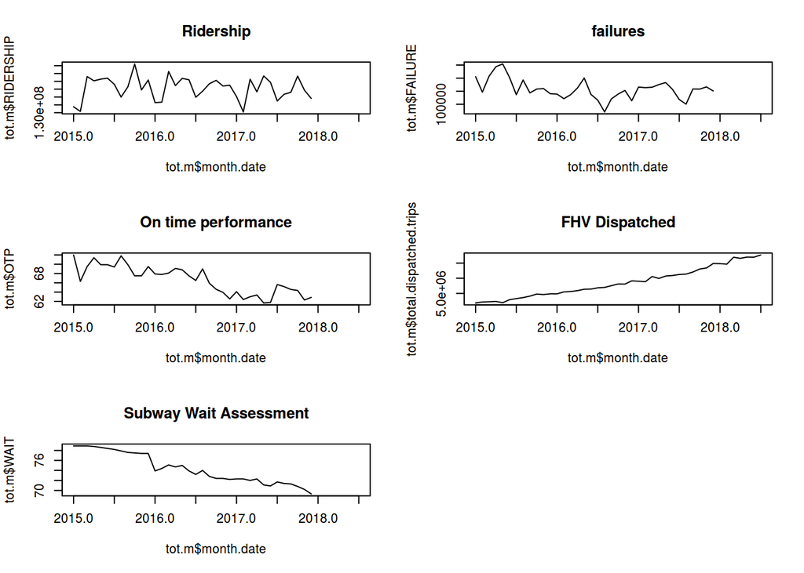

```r
par(mfrow = c(3,2))
plot.zoo(tot.m$month.date, tot.m$RIDERSHIP, type = 'l', main = "Ridership")
plot.zoo(tot.m$month.date, tot.m$FAILURE, type = 'l', main ="failures")
plot.zoo(tot.m$month.date, tot.m$OTP, type = 'l', main = "On time performance")
plot.zoo(tot.m$month.date, tot.m$total.dispatched.trips, type = 'l', main = "FHV Dispatched")
plot.zoo(tot.m$month.date, tot.m$WAIT, type = 'l', main = "Subway Wait Assessment")
```

Analyze seasonality and trend for the response and predictor variables as they are all temporal.

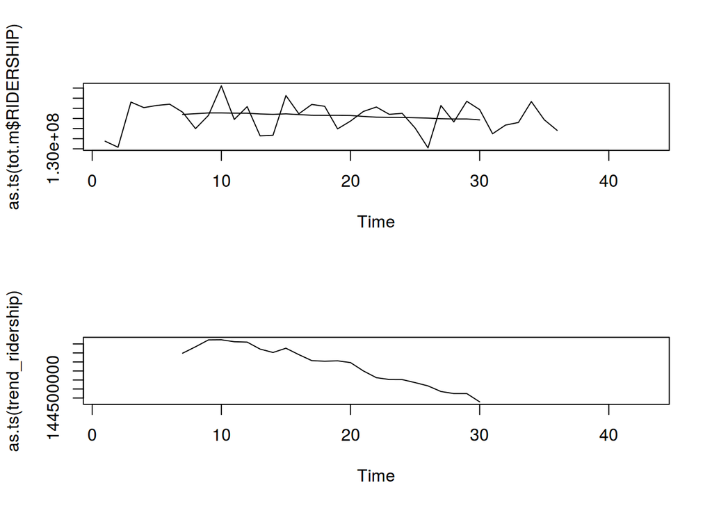

```r
trend_ridership <- ma(tot.m$RIDERSHIP, order = 12, centre = TRUE)
par(mfrow = c(2,1))
plot(as.ts(tot.m$RIDERSHIP))
lines(trend_ridership)
plot(as.ts(trend_ridership))
```

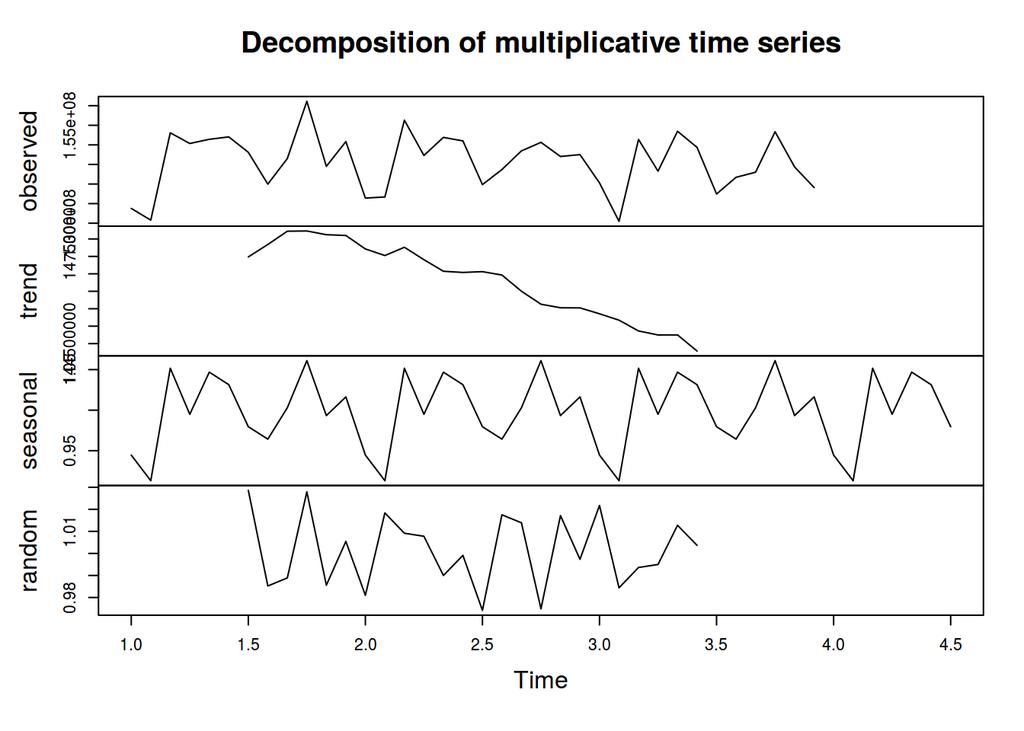

```r
ts_ride <- ts(tot.m$RIDERSHIP, frequency = 12)
ts.fhv <- ts(tot.m$total.dispatched.trips, frequency = 12)
ts.fail <- ts(tot.m$FAILURE, frequency = 12)
ts.otp <- ts(tot.m$OTP, frequency = 12)
ts.wait <- ts(tot.m$WAIT, frequency = 12)

ts.ride.de <- decompose(ts_ride, "multiplicative")
ts.fhv.de <- decompose(ts.fhv, "multiplicative")
ts.fail.de <- decompose(ts.fail, "multiplicative")
ts.otp.de <- decompose(ts.otp, "multiplicative")

#plot ridership deconstructed time series
plot(decompose(ts_ride, "multiplicative"))
```

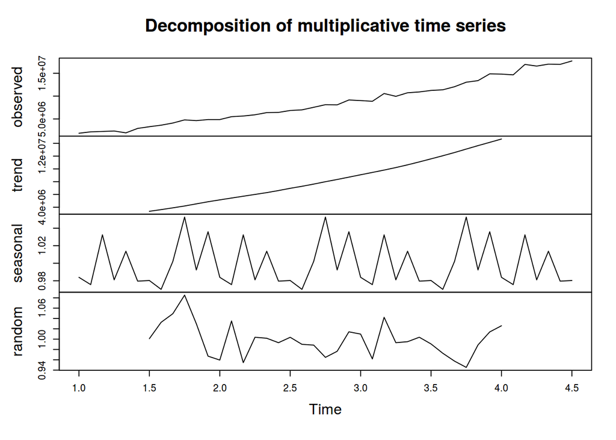

```r
#plot ride hailing dispatched trips deconstructed time series
plot(decompose(ts.fhv, "multiplicative"))
```

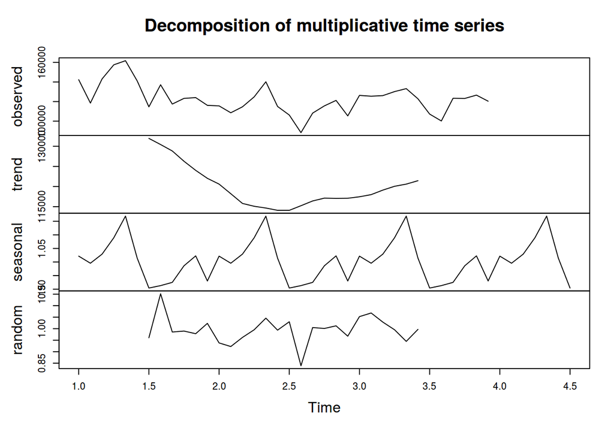

```r
#plot failure MTA deconstructed time series
plot(decompose(ts.fail, "multiplicative"))
```

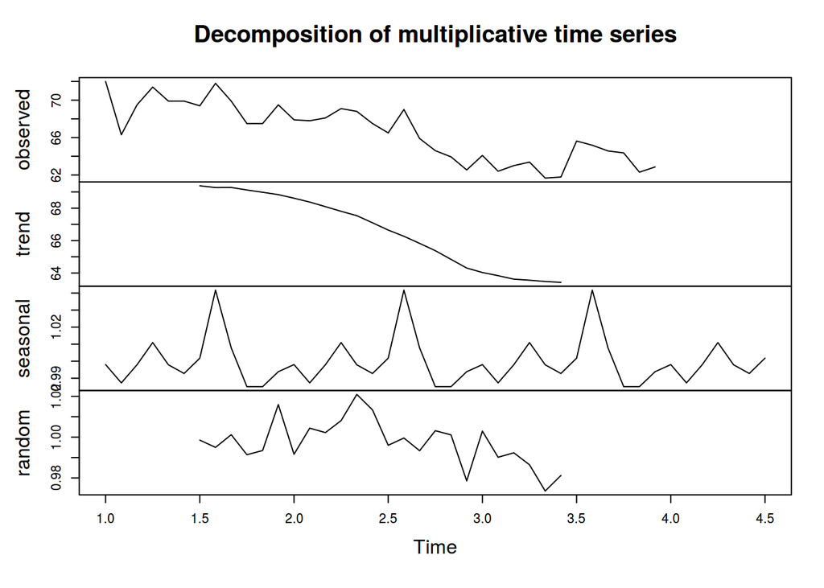

```r
#plot on time performance deconstructed time series
plot(decompose(ts.otp, "multiplicative"))
```

Look at the autocorrelation tendencies from each variable.

```r
head(ts.ride.de$random)
```

```
##   Jan Feb Mar Apr May Jun
## 1  NA  NA  NA  NA  NA  NA
```

```r
#acf(ts.ride.de$random)
```

**Error** encountered!

Initially… my desire was to build two models: 1) The first model is built using the entirely decomposed time series with trend and seasonality removed. 2) Second model is built using the trend datasets (with seasonality removed) from each variable.

```r
tot.m %>%
  dplyr::select(-INJURY) -> temp

temp[complete.cases(temp)] -> tot.m.cc

head(tot.m.cc)
```

```
##    Year Month total.dispatched.trips FAILURE RIDERSHIP ELEV ESCA  OTP WAIT
## 1: 2015     1                1871075  142317 133769924 96.4 94.5 72.0 78.9
## 2: 2015     2                2178305  118482 130778251 96.5 94.5 66.3 78.9
## 3: 2015     3                2259575  143146 153076928 96.5 94.1 69.5 78.9
## 4: 2015     4                2360945  157519 150348150 96.5 94.0 71.4 78.8
## 5: 2015     5                1955553  161720 151418931 97.3 94.3 69.9 78.6
## 6: 2015     6                2927683  141061 152034275 96.4 93.9 69.9 78.4
##    month.date
## 1:   Jan 2015
## 2:   Feb 2015
## 3:   Mar 2015
## 4:   Apr 2015
## 5:   May 2015
## 6:   Jun 2015
```

```r
lagged.set = data.frame(
  ridership = tot.m.cc$RIDERSHIP[1:length(tot.m.cc$RIDERSHIP)-1],
fhv = tot.m.cc$total.dispatched.trips[2:36],
failure = tot.m.cc$FAILURE[2:36],
otp = tot.m.cc$OTP[2:36],
wait = tot.m.cc$WAIT[2:36])

head(lagged.set)
```

```
##   ridership     fhv failure  otp wait
## 1 133769924 2178305  118482 66.3 78.9
## 2 130778251 2259575  143146 69.5 78.9
## 3 153076928 2360945  157519 71.4 78.8
## 4 150348150 1955553  161720 69.9 78.6
## 5 151418931 2927683  141061 69.9 78.4
## 6 152034275 3302373  114591 69.4 78.2
```

```r
model.ts <- lm(data = lagged.set, ridership ~ .)

summary(model.ts)
```

```
##
## Call:
## lm(formula = ridership ~ ., data = lagged.set)
##
## Residuals:
##       Min        1Q    Median        3Q       Max
## -16082778  -4103933    665770   4516948  17582378
##
## Coefficients:
##               Estimate Std. Error t value Pr(>|t|)
## (Intercept)  2.179e+08  1.138e+08   1.914   0.0652 .
## fhv         -8.006e-01  1.178e+00  -0.679   0.5021
## failure      1.382e+02  9.596e+01   1.440   0.1602
## otp          7.001e+05  8.242e+05   0.849   0.4024
## wait        -1.745e+06  1.556e+06  -1.122   0.2710
## ---
## Signif. codes:  0 '***' 0.001 '**' 0.01 '*' 0.05 '.' 0.1 ' ' 1
##
## Residual standard error: 7343000 on 30 degrees of freedom
## Multiple R-squared:  0.08393,    Adjusted R-squared:  -0.03821
## F-statistic: 0.6872 on 4 and 30 DF,  p-value: 0.6065
```

Wow, the model is hot garbage!

Model diagnostics

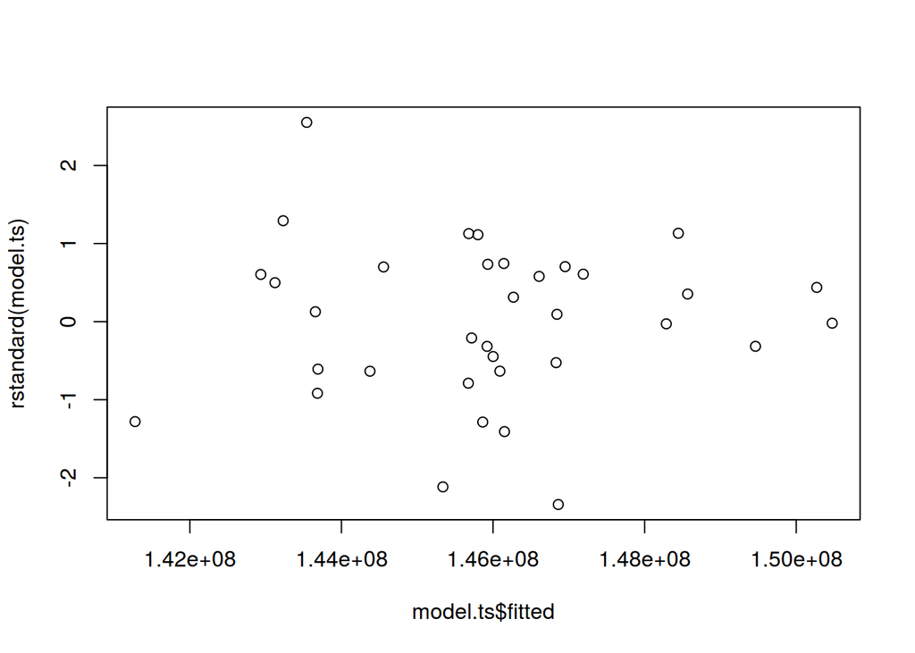

```r
par(mfrow=c(1,1))
plot(model.ts$fitted, rstandard(model.ts))
```

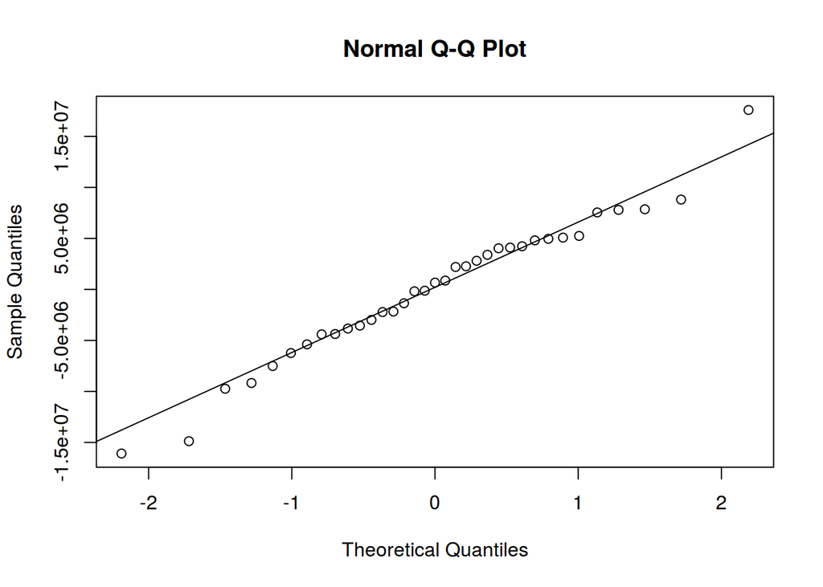

```r
qqnorm(residuals(model.ts))
qqline(residuals(model.ts))
```

Treat the response variable, then re-fit.

```r
model.ts.sqrt <- lm(data = lagged.set, I(log(ridership) ~ .))

summary(model.ts.sqrt)
```

```
##
## Call:
## lm(formula = I(log(ridership) ~ .), data = lagged.set)
##
## Residuals:
##       Min        1Q    Median        3Q       Max
## -0.113969 -0.027990  0.005528  0.031644  0.117644
##
## Coefficients:
##               Estimate Std. Error t value Pr(>|t|)
## (Intercept)  1.931e+01  7.889e-01  24.472   <2e-16 ***
## fhv         -5.561e-09  8.166e-09  -0.681    0.501
## failure      9.559e-07  6.650e-07   1.438    0.161
## otp          5.093e-03  5.712e-03   0.892    0.380
## wait        -1.245e-02  1.078e-02  -1.155    0.257
## ---
## Signif. codes:  0 '***' 0.001 '**' 0.01 '*' 0.05 '.' 0.1 ' ' 1
##
## Residual standard error: 0.05089 on 30 degrees of freedom
## Multiple R-squared:  0.08537,    Adjusted R-squared:  -0.03658
## F-statistic:   0.7 on 4 and 30 DF,  p-value: 0.598
```

Fit a generalized least squares model

```r
summary(gls(data = lagged.set, ridership ~ .))
```

```
## Generalized least squares fit by REML
##   Model: ridership ~ .
##   Data: lagged.set
##        AIC      BIC    logLik
##   1113.199 1121.606 -550.5993
##
## Coefficients:
##                 Value Std.Error    t-value p-value
## (Intercept) 217874484 113844757  1.9137858  0.0652
## fhv                -1         1 -0.6794352  0.5021
## failure           138        96  1.4402452  0.1602
## otp            700086    824226  0.8493853  0.4024
## wait         -1744526   1555502 -1.1215194  0.2710
##
##  Correlation:
##         (Intr) fhv    failur otp
## fhv     -0.961
## failure  0.203 -0.194
## otp     -0.142  0.126  0.157
## wait    -0.867  0.832 -0.362 -0.359
##
## Standardized residuals:
##         Min          Q1         Med          Q3         Max
## -2.19017342 -0.55887887  0.09066541  0.61512381  2.39439076
##
## Residual standard error: 7343153
## Degrees of freedom: 35 total; 30 residual
```

Iden’s model

```r
fs.cc <- final.subway[complete.cases(final.subway),]
model <- lm(OTP ~ FAILURE + RIDERSHIP + INJURY + ELEV + ESCA, data = fs.cc)

summary(model)
```

```
##
## Call:
## lm(formula = OTP ~ FAILURE + RIDERSHIP + INJURY + ELEV + ESCA,
##     data = fs.cc)
##
## Residuals:
##      Min       1Q   Median       3Q      Max
## -11.2324  -3.5214  -0.0817   2.9602  11.8279
##
## Coefficients:
##               Estimate Std. Error t value Pr(>|t|)
## (Intercept) -1.735e+02  7.285e+01  -2.382   0.0192 *
## FAILURE      1.582e-04  1.890e-05   8.369 5.34e-13 ***
## RIDERSHIP   -3.371e-07  7.612e-08  -4.428 2.56e-05 ***
## INJURY      -1.728e+00  1.603e+00  -1.078   0.2837
## ELEV         3.470e+00  7.784e-01   4.457 2.29e-05 ***
## ESCA        -5.904e-01  4.241e-01  -1.392   0.1671
## ---
## Signif. codes:  0 '***' 0.001 '**' 0.01 '*' 0.05 '.' 0.1 ' ' 1
##
## Residual standard error: 5.122 on 94 degrees of freedom
## Multiple R-squared:  0.7036, Adjusted R-squared:  0.6878
## F-statistic: 44.62 on 5 and 94 DF,  p-value: < 2.2e-16
```

Plot the residuals… looks like there is a pattern of the residuals… almost a negative quadratic

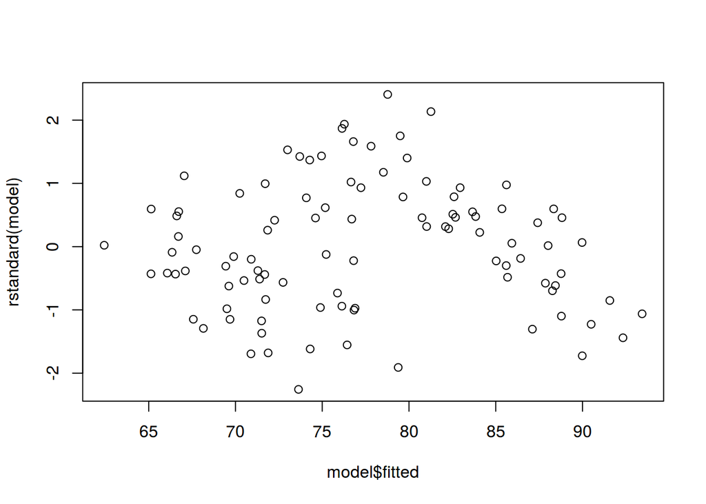

```r
par(mfrow= c(1,1))
plot(model$fitted, rstandard(model))
```

Plot each variable against the residuals

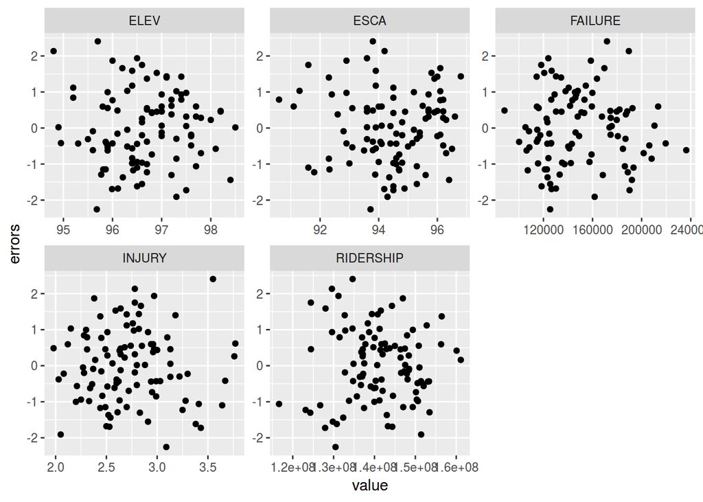

```r
fs.cc %>%
  dplyr::select(FAILURE, RIDERSHIP, ELEV, ESCA, INJURY) %>%
  gather() -> long.form

long.form$errors <- rep(rstandard(model),5)

ggplot(long.form,aes(x = value, y = errors)) +geom_point() + facet_wrap(~key, scales = "free")
```